# Claude로 하는 분류: 보험 지원 티켓 분류기

이 가이드에서는 보험 지원 티켓을 10개 범주로 분류하는 고정확도 분류 시스템을 만듭니다. 프롬프트 엔지니어링, 검색 증강 생성(RAG), 생각의 사슬 추론을 결합해 분류 정확도를 70%에서 95% 이상으로 단계적으로 끌어올리는 방법을 배웁니다.

이 가이드를 마치면 복잡한 비즈니스 규칙을 다루고, 학습 데이터가 부족한 상황에서도 동작하며, 설명 가능한 결과를 내놓는 분류 시스템을 설계하는 방법을 이해하게 됩니다.

## 사전 준비

- Python 3.11 이상과 기본적인 친숙함
- Anthropic API 키 ([여기서 발급](https://console.anthropic.com))
- VoyageAI API 키 (선택 — 임베딩은 미리 계산되어 있습니다)
- 분류 문제에 대한 이해

## 준비

먼저 필요한 패키지를 설치합니다

- anthropic
- voyageai
- pandas
- matplotlib
- sklearn
- numpy

환경에서 API 키를 불러오고 모델 이름도 설정합니다.

```python
%%capture
!pip install -U anthropic voyageai pandas numpy matplotlib scikit-learn
```

```python
# Setup our environment
import os

import anthropic

MODEL = "claude-haiku-4-5"
client = anthropic.Anthropic(
    # This is the default and can be omitted
    api_key=os.getenv("ANTHROPIC_API_KEY"),
)
```

## Claude로 하는 분류

대규모 언어 모델(LLM)은 분류 분야에 혁신을 가져왔습니다. 특히 전통적인 머신러닝 시스템이 어려움을 겪던 영역에서 그렇습니다. LLM은 복잡한 비즈니스 규칙이 얽힌 분류 문제, 그리고 학습 데이터의 품질이 낮거나 양이 적은 상황에서 눈에 띄는 성공을 거뒀습니다. 게다가 LLM은 자신의 판단에 대해 자연어로 설명과 근거를 제시할 수 있어 분류 과정의 해석 가능성과 투명성을 높여 줍니다. LLM의 힘을 활용하면 전통적인 머신러닝 접근을 넘어서는 분류 시스템을 만들 수 있고, 데이터가 부족하거나 비즈니스 요구가 복잡한 상황에서 특히 빛을 발합니다.

이 가이드에서는 고급 분류 작업에 LLM을 활용하는 방법을 살펴봅니다. 다음 핵심 구성 요소와 단계를 다룹니다.

1. **데이터 준비**: 먼저 학습 데이터와 테스트 데이터를 준비합니다. 학습 데이터로 분류 모델을 만들고, 테스트 데이터로 성능을 평가합니다. 분류 시스템의 효과를 보장하려면 데이터 준비가 중요합니다.
2. **프롬프트 엔지니어링**: 분류에 LLM의 힘을 끌어내는 데 프롬프트 엔지니어링이 결정적인 역할을 합니다. 분류에 사용할 프롬프트의 구조와 형식을 정의하는 프롬프트 템플릿을 설계합니다. 이 템플릿에는 사용자 질의, 범주 정의, 그리고 벡터 데이터베이스에서 가져온 관련 예시가 담깁니다. 프롬프트를 세심하게 설계하면 LLM이 정확하고 맥락에 맞는 분류를 생성하도록 이끌 수 있습니다.
3. **검색 증강 생성(RAG) 구현**: 분류 과정을 개선하기 위해 학습 데이터의 임베딩을 저장하고 효율적으로 검색하는 벡터 데이터베이스를 사용합니다. 벡터 데이터베이스는 유사도 검색을 가능하게 해, 주어진 질의에 가장 관련 있는 예시를 찾아 줍니다. 검색된 예시로 LLM을 보강하면 추가 맥락을 제공하고 생성되는 분류의 정확도를 높일 수 있습니다.
4. **테스트와 평가**: 분류 시스템을 만든 뒤에는 변환된 테스트 데이터로 성능을 엄밀하게 시험합니다. 테스트 질의를 순회하며 분류 함수로 각각을 분류하고, 예측 범주와 기대 범주를 비교합니다. 분류 결과를 분석해 시스템의 효과를 평가하고 개선할 지점을 찾아냅니다.

## 문제 정의: 보험 지원 티켓 분류기

*참고: 이 예제의 문제 정의, 데이터, 레이블은 Claude 3 Opus가 합성으로 생성한 것입니다*

보험 업계에서 고객 지원은 고객 만족과 유지에 결정적인 역할을 합니다. 보험사는 매일 청구, 계약 관리, 보험금 청구 지원 등 다양한 주제의 지원 티켓을 대량으로 받습니다. 이 티켓들을 수작업으로 분류하면 시간이 많이 들고 비효율적이어서 응답 시간이 길어지고 고객 경험에 영향을 줄 수 있습니다.

#### 범주 정의

1. 청구 문의
- 청구서, 부과 금액, 수수료, 보험료에 대한 질문
- 청구 명세서 설명 요청
- 결제 수단과 납부 기한에 대한 문의
2. 계약 관리
- 계약 변경, 갱신 정보 수정, 해지 요청
- 계약 갱신과 부활에 대한 질문
- 보장 옵션 추가·삭제에 대한 문의
3. 보험금 청구 지원
- 청구 절차와 접수 방법에 대한 질문
- 청구 서류 제출 도움 요청
- 청구 진행 상태와 지급 일정에 대한 문의
4. 보장 내용 설명
- 특정 계약 유형에서 무엇이 보장되는지에 대한 질문
- 보장 한도와 면책 사항 설명 요청
- 자기부담금과 본인 부담 비용에 대한 문의
5. 견적과 제안
- 신규 계약 견적과 가격 비교 요청
- 이용 가능한 할인과 묶음 상품에 대한 질문
- 다른 보험사에서 옮겨 오는 것에 대한 문의
6. 계정 관리
- 로그인 정보나 비밀번호 재설정 요청
- 온라인 계정 기능과 사용법에 대한 질문
- 연락처나 개인정보 수정에 대한 문의
7. 청구 이의
- 예상치 못했거나 잘못된 부과에 대한 불만
- 환불이나 보험료 조정 요청
- 연체료나 독촉 안내에 대한 문의
8. 보험금 청구 이의
- 지급 거절되거나 과소 지급된 청구에 대한 불만
- 청구 결정 재검토 요청
- 청구 결과에 대한 이의 제기 문의
9. 상품 비교
- 계약 옵션 간 차이에 대한 질문
- 보장 수준 선택에 대한 도움 요청
- 경쟁사 상품과의 비교에 대한 문의
10. 일반 문의
- 회사 연락처나 영업시간에 대한 질문
- 상품이나 서비스에 대한 일반 정보 요청
- 다른 범주에 딱 들어맞지 않는 문의

## 데이터 불러오고 준비하기

문제와 범주를 정의했으니 레이블이 붙은 학습·테스트 데이터를 불러오겠습니다. TSV 파일을 읽어 구조화된 형태로 바꾸고, 평가를 위한 테스트 세트를 준비합니다.

학습 데이터에는 나중에 검색 증강 생성(RAG)에 사용할 레이블 예시 68개가 들어 있습니다. 테스트 세트에도 분류 방식을 평가할 예시 68개가 있습니다.

다음 데이터셋을 사용합니다.

- `./data/test.tsv`
- `./data/train.tsv`

```python
import pandas as pd

data = {
    "train": [],
    "test": [],
}


# Helper function to convert a DataFrame to a list of dictionaries
def dataframe_to_dict_list(df):
    return df.apply(lambda x: {"text": x["text"], "label": x["label"]}, axis=1).tolist()


# Read the TSV file into a DataFrame
test_df = pd.read_csv("./data/test.tsv", sep="\t")
data["test"] = dataframe_to_dict_list(test_df)

train_df = pd.read_csv("./data/train.tsv", sep="\t")
data["train"] = dataframe_to_dict_list(train_df)


# Understand the labels in the dataset
labels = list(set(train_df["label"].unique()))

# Print the first training example and the number of training examples
print(data["train"][0], len(data["train"]))

# Create the test set
X_test = [example["text"] for example in data["test"]]
y_test = [example["label"] for example in data["test"]]

# Print the length of the test set
print(len(X_test), len(y_test))
```

```
{'text': 'I just got my auto policy renewal bill and the cost seems to be more than what I usually pay. Could you explain the reason for the increase?', 'label': 'Billing Inquiries'} 68
68 68
```

## 평가 프레임워크

분류기를 만들기 전에 성능을 측정할 평가 프레임워크를 준비하겠습니다. 두 개의 핵심 함수를 만듭니다.

1. **`evaluate(X, y, classifier, batch_size)`**: 속도를 위해 동시 실행으로 모든 테스트 예시에 분류기를 돌린 뒤 정확도 지표를 계산하고 혼동 행렬을 생성합니다. `batch_size` 파라미터가 동시 API 요청 수를 제어합니다.
2. **`plot_confusion_matrix(cm, labels)`**: 혼동 행렬을 시각화해 어떤 범주끼리 혼동되는지 보여 주어, 분류기가 어디서 어려움을 겪는지 파악하게 해 줍니다.

이 프레임워크 덕분에 여러 분류 방식을 경험적으로 비교하고, 전체 정확도뿐 아니라 어떤 범주가 까다로운지도 이해할 수 있습니다.

```python
import concurrent.futures

import matplotlib.pyplot as plt
import numpy as np
from sklearn.metrics import classification_report, confusion_matrix

MAXIMUM_CONCURRENT_REQUESTS = 5


def plot_confusion_matrix(cm, labels):
    # Visualize the confusion matrix
    fig, ax = plt.subplots(figsize=(8, 8))
    im = ax.imshow(cm, cmap="Blues")

    # Add colorbar
    ax.figure.colorbar(im, ax=ax)

    # Set tick labels and positions
    ax.set_xticks(np.arange(len(labels)))
    ax.set_yticks(np.arange(len(labels)))
    ax.set_xticklabels(labels, rotation=45, ha="right")
    ax.set_yticklabels(labels)

    # Add labels to each cell
    thresh = cm.max() / 2.0
    for i in range(len(labels)):
        for j in range(len(labels)):
            ax.text(
                j,
                i,
                cm[i, j],
                ha="center",
                va="center",
                color="white" if cm[i, j] > thresh else "black",
            )

    # Set labels and title
    plt.xlabel("Predicted Labels")
    plt.ylabel("True Labels")
    plt.title("Confusion Matrix")
    plt.tight_layout()
    plt.show()


def evaluate(X, y, classifier, batch_size=MAXIMUM_CONCURRENT_REQUESTS):
    # Initialize lists to store the predicted and true labels
    y_true = []
    y_pred = []

    # Store results with their original index to maintain order
    results = [None] * len(X)

    # Create a ThreadPoolExecutor with limited workers
    with concurrent.futures.ThreadPoolExecutor(max_workers=batch_size) as executor:
        # Submit tasks one at a time, but executor will only run batch_size concurrently
        future_to_index = {executor.submit(classifier, x): i for i, x in enumerate(X)}

        # Process results as they complete
        for future in concurrent.futures.as_completed(future_to_index):
            index = future_to_index[future]
            predicted_label = future.result()
            results[index] = predicted_label

    # Extract predictions and true labels in order
    y_pred = results
    y_true = y

    # Normalize y_true and y_pred
    y_true = [label.strip() for label in y_true]
    y_pred = [label.strip() for label in y_pred]

    # Calculate the classification metrics
    report = classification_report(y_true, y_pred, labels=labels, zero_division=1)
    cm = confusion_matrix(y_true, y_pred, labels=labels)
    print(report)
    plot_confusion_matrix(cm, labels)
```

## 기준점: 무작위 분류기

성능 기준을 세우고 평가 프레임워크가 제대로 동작하는지 확인하기 위해, 티켓마다 범주를 무작위로 고르는 분류기부터 시작하겠습니다.

이것이 성능의 하한선이 됩니다. 실제 분류 방식이라면 무작위 추측(범주가 10개이므로 약 10% 정확도)보다 훨씬 나아야 합니다. 이 기준점이 우리의 맥락 설계가 실제로 얼마나 가치를 더하는지 수치로 보여 줍니다.

```python
import random


def random_classifier(text):
    return random.choice(labels)
```

```
Evaluating the random classification method on the test set...
                       precision    recall  f1-score   support

    Claims Assistance       0.14      0.17      0.15         6
 Quotes and Proposals       0.40      0.40      0.40         5
      Claims Disputes       0.38      0.33      0.35         9
Coverage Explanations       0.29      0.22      0.25         9
     Billing Disputes       0.20      0.11      0.14         9
Policy Administration       0.25      0.33      0.29         6
    Billing Inquiries       0.00      0.00      0.00         6
    General Inquiries       0.00      0.00      0.00         7
   Policy Comparisons       0.00      0.00      0.00         5
   Account Management       0.00      0.00      0.00         6

             accuracy                           0.16        68
            macro avg       0.17      0.16      0.16        68
         weighted avg       0.18      0.16      0.17        68
```

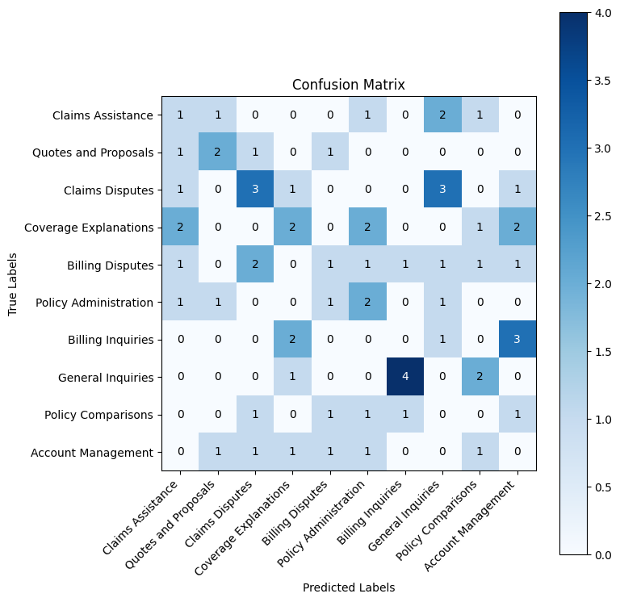

```python
print("Evaluating the random classification method on the test set...")
evaluate(X_test, y_test, random_classifier)
```

### 간단한 분류 테스트

이제 Claude로 간단한 분류기를 만들어 보겠습니다.

먼저 범주를 XML 형식으로 인코딩합니다. Claude가 정보를 해석하기 쉬워집니다. 정보를 XML로 인코딩하는 것은 일반적인 프롬프팅 전략이며, 자세한 내용은 [여기](https://docs.claude.com/en/docs/build-with-claude/prompt-engineering/use-xml-tags)를 참고하세요

```python
import textwrap

categories = textwrap.dedent("""<category>
    <label>Billing Inquiries</label>
    <content> Questions about invoices, charges, fees, and premiums Requests for clarification on billing statements Inquiries about payment methods and due dates
    </content>
</category>
<category>
    <label>Policy Administration</label>
    <content> Requests for policy changes, updates, or cancellations Questions about policy renewals and reinstatements Inquiries about adding or removing coverage options
    </content>
</category>
<category>
    <label>Claims Assistance</label>
    <content> Questions about the claims process and filing procedures Requests for help with submitting claim documentation Inquiries about claim status and payout timelines
    </content>
</category>
<category>
    <label>Coverage Explanations</label>
    <content> Questions about what is covered under specific policy types Requests for clarification on coverage limits and exclusions Inquiries about deductibles and out-of-pocket expenses
    </content>
</category>
<category>
    <label>Quotes and Proposals</label>
    <content> Requests for new policy quotes and price comparisons Questions about available discounts and bundling options Inquiries about switching from another insurer
    </content>
</category>
<category>
    <label>Account Management</label>
    <content> Requests for login credentials or password resets Questions about online account features and functionality Inquiries about updating contact or personal information
    </content>
</category>
<category>
    <label>Billing Disputes</label>
    <content> Complaints about unexpected or incorrect charges Requests for refunds or premium adjustments Inquiries about late fees or collection notices
    </content>
</category>
<category>
    <label>Claims Disputes</label>
    <content> Complaints about denied or underpaid claims Requests for reconsideration of claim decisions Inquiries about appealing a claim outcome
    </content>
</category>
<category>
    <label>Policy Comparisons</label>
    <content> Questions about the differences between policy options Requests for help deciding between coverage levels Inquiries about how policies compare to competitors' offerings
    </content>
</category>
<category>
    <label>General Inquiries</label>
    <content> Questions about company contact information or hours of operation Requests for general information about products or services Inquiries that don't fit neatly into other categories
    </content>
</category>""")
```

## 간단한 분류기 만들기

이제 Claude로 첫 실제 분류기를 만들어 보겠습니다. `simple_classify` 함수는 세 가지 핵심 프롬프트 엔지니어링 기법을 보여 줍니다.

1. **구조화된 프롬프트 템플릿**: 범주 정의와 지원 티켓을 명확한 XML 형식으로 제공해 Claude가 정보를 파싱하기 쉽게 만듭니다.
2. **프리필로 출력 제어하기**: assistant 응답을 `<category>`로 시작하고 `stop_sequences=["</category>"]`를 설정하면, Claude가 설명이나 부가 텍스트 없이 범주 레이블만 출력하게 됩니다. 응답 파싱이 안정적이고 결정론적이 됩니다.
3. **결정론적 분류**: `temperature=0.0`으로 설정하면 같은 입력에 대해 일관된 예측이 나오며, 분류 작업에서는 이것이 결정적입니다.

```python
def simple_classify(X):
    prompt = (
        textwrap.dedent("""
    You will classify a customer support ticket into one of the following categories:
    <categories>
        {{categories}}
    </categories>

    Here is the customer support ticket:
    <ticket>
        {{ticket}}
    </ticket>

    Respond with just the label of the category between category tags.
    """)
        .replace("{{categories}}", categories)
        .replace("{{ticket}}", X)
    )
    response = client.messages.create(
        messages=[
            {"role": "user", "content": prompt},
            {"role": "assistant", "content": "<category>"},
        ],
        stop_sequences=["</category>"],
        max_tokens=4096,
        temperature=0.0,
        model=MODEL,
    )

    # Extract the result from the response
    result = response.content[0].text  # pyright: ignore[reportAttributeAccessIssue]
    return result.strip()
```

```
Evaluating the simple classification method on the test set...
                       precision    recall  f1-score   support

    Claims Assistance       1.00      0.67      0.80         6
 Quotes and Proposals       1.00      0.60      0.75         5
      Claims Disputes       1.00      1.00      1.00         9
Coverage Explanations       0.53      1.00      0.69         9
     Billing Disputes       0.67      0.67      0.67         9
Policy Administration       0.71      0.83      0.77         6
    Billing Inquiries       0.50      0.50      0.50         6
    General Inquiries       1.00      0.00      0.00         7
   Policy Comparisons       0.71      1.00      0.83         5
   Account Management       1.00      1.00      1.00         6

             accuracy                           0.74        68
            macro avg       0.81      0.73      0.70        68
         weighted avg       0.80      0.74      0.70        68
```

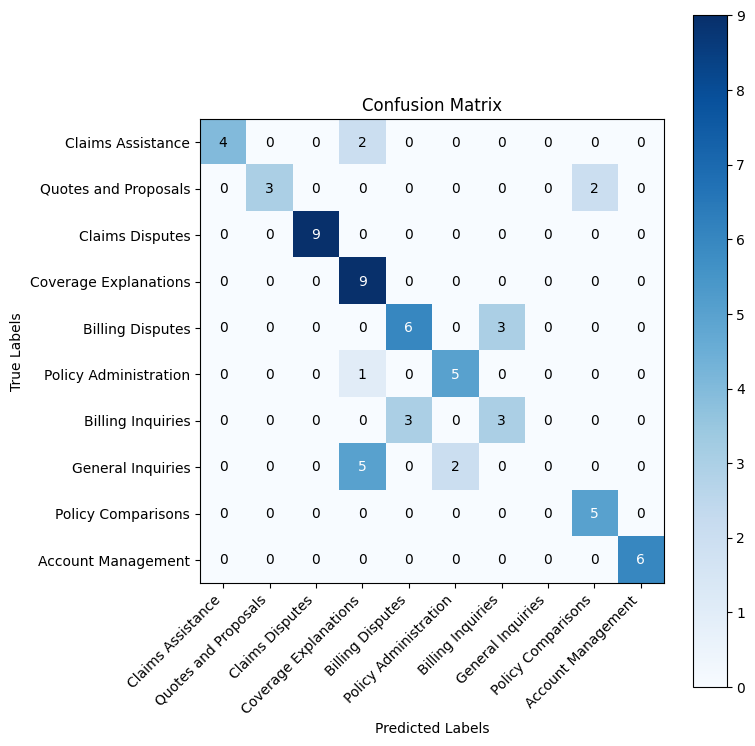

```python
print("Evaluating the simple classification method on the test set...")
evaluate(X_test, y_test, simple_classify)
```

훨씬 낫습니다! 혼동 행렬에 뚜렷한 대각선 패턴이 나타나고 대부분의 범주가 높은 정확도를 보입니다.

약 70%의 전체 정확도는 무작위 추측을 크게 앞서지만, 비슷한 범주끼리의 혼동은 더 세밀한 구분을 위해 Claude에 더 많은 맥락이 필요하다는 신호입니다.

이 혼동 패턴을 해결하기 위해 학습 데이터에서 가져온 관련 예시를 Claude에 제공하는 **검색 증강 생성(RAG)**을 더하겠습니다. 동작 방식은 다음과 같습니다.

1. **학습 예시 임베딩**: VoyageAI 임베딩 모델로 학습 티켓 68개를 모두 벡터 임베딩으로 변환합니다
2. **시맨틱 검색**: 새 티켓마다 코사인 유사도로 가장 비슷한 학습 예시 5개를 찾습니다
3. **프롬프트 보강**: 이 유사 예시들을 분류 프롬프트에 넣어 Claude를 이끕니다

이 방식이 분류에 특히 효과적인 이유는 다음과 같습니다.

- 비슷한 과거 예시가 의미적으로 가까운 범주를 구분하는 데 도움이 됩니다
- 파인튜닝 없이 퓨샷 러닝으로 정확도가 올라갑니다
- 검색이 동적이어서 질의마다 가장 관련 있는 예시를 얻습니다

[VoyageAI 임베딩 모델](https://docs.claude.com/en/docs/embeddings)로 임베딩 저장과 유사도 검색을 처리하는 간단한 `VectorDB` 클래스를 만들겠습니다.

```python
import json
import os
import pickle

import numpy as np
import voyageai


class VectorDB:
    def __init__(self, api_key=None):
        if api_key is None:
            api_key = os.getenv("VOYAGE_API_KEY")
        self.client = voyageai.Client(api_key=api_key)
        self.embeddings = []
        self.metadata = []
        self.query_cache = {}
        self.db_path = "./data/vector_db.pkl"

    def load_data(self, data):
        # Check if the vector database is already loaded
        if self.embeddings and self.metadata:
            print("Vector database is already loaded. Skipping data loading.")
            return
        # Check if vector_db.pkl exists
        if os.path.exists(self.db_path):
            print("Loading vector database from disk.")
            self.load_db()
            return

        texts = [item["text"] for item in data]

        # Embed more than 128 documents with a for loop
        batch_size = 128
        result = [
            self.client.embed(texts[i : i + batch_size], model="voyage-2").embeddings
            for i in range(0, len(texts), batch_size)
        ]

        # Flatten the embeddings
        self.embeddings = [embedding for batch in result for embedding in batch]
        self.metadata = [item for item in data]
        self.save_db()
        # Save the vector database to disk
        print("Vector database loaded and saved.")

    def search(self, query, k=5, similarity_threshold=0.75):
        query_embedding = None
        if query in self.query_cache:
            query_embedding = self.query_cache[query]
        else:
            query_embedding = self.client.embed([query], model="voyage-2").embeddings[0]
            self.query_cache[query] = query_embedding

        if not self.embeddings:
            raise ValueError("No data loaded in the vector database.")

        similarities = np.dot(self.embeddings, query_embedding)
        top_indices = np.argsort(similarities)[::-1]
        top_examples = []

        for idx in top_indices:
            if similarities[idx] >= similarity_threshold:
                example = {
                    "metadata": self.metadata[idx],
                    "similarity": similarities[idx],
                }
                top_examples.append(example)

                if len(top_examples) >= k:
                    break
        self.save_db()
        return top_examples

    def save_db(self):
        data = {
            "embeddings": self.embeddings,
            "metadata": self.metadata,
            "query_cache": json.dumps(self.query_cache),
        }
        with open(self.db_path, "wb") as file:
            pickle.dump(data, file)

    def load_db(self):
        if not os.path.exists(self.db_path):
            raise ValueError(
                "Vector database file not found. Use load_data to create a new database."
            )

        with open(self.db_path, "rb") as file:
            data = pickle.load(file)

        self.embeddings = data["embeddings"]
        self.metadata = data["metadata"]
        self.query_cache = json.loads(data["query_cache"])
```

벡터 DB를 정의하고 학습 데이터를 불러올 수 있습니다.

VoyageAI는 신용카드가 등록되지 않은 계정에 분당 3회 요청 한도를 둡니다. 시연의 편의를 위해 캐시를 활용합니다.

```python
vectordb = VectorDB()
vectordb.load_data(data["train"])
```

```
Loading vector database from disk.
```

## RAG로 강화한 분류기

이제 검색 증강 생성으로 분류기를 다시 만들어 보겠습니다. `rag_classify` 함수는 다음과 같이 간단한 분류기를 강화합니다.

1. **유사 예시 검색**: 티켓마다 벡터 데이터베이스에서 의미적으로 가장 비슷한 학습 예시 5개를 찾습니다
2. **퓨샷 예시로 형식화**: 이 예시들을 `<query>`와 `<label>` 태그를 사용한 XML 형식으로 구성해, 비슷한 티켓이 어떻게 분류되었는지 Claude에 보여 줍니다
3. **프롬프트 보강**: 새 티켓 분류를 요청하기 전에 이 예시들을 프롬프트에 주입합니다

이 퓨샷 러닝 방식은 비슷한 표현의 티켓이 어떻게 분류되어야 하는지 구체적인 예시로 보여 주어, Claude가 유사한 범주를 더 잘 구분하게 돕습니다. 예를 들어 테스트 티켓에 "예상치 못한 부과"가 언급되면, 과거의 "청구 이의"와 "청구 문의" 예시를 가져오는 것이 Claude가 그 미묘한 차이를 이해하는 데 도움이 됩니다.

앞선 실행에서 혼동되던 범주들의 정확도가 얼마나 개선되는지 살펴보겠습니다.

```python
def rag_classify(X):
    rag = vectordb.search(X, 5)
    rag_string = ""
    for example in rag:
        rag_string += textwrap.dedent(f"""
        <example>
            <query>
                "{example["metadata"]["text"]}"
            </query>
            <label>
                {example["metadata"]["label"]}
            </label>
        </example>
        """)
    prompt = (
        textwrap.dedent("""
    You will classify a customer support ticket into one of the following categories:
    <categories>
        {{categories}}
    </categories>

    Here is the customer support ticket:
    <ticket>
        {{ticket}}
    </ticket>

    Use the following examples to help you classify the query:
    <examples>
        {{examples}}
    </examples>

    Respond with just the label of the category between category tags.
    """)
        .replace("{{categories}}", categories)
        .replace("{{ticket}}", X)
        .replace("{{examples}}", rag_string)
    )
    response = client.messages.create(
        messages=[
            {"role": "user", "content": prompt},
            {"role": "assistant", "content": "<category>"},
        ],
        stop_sequences=["</category>"],
        max_tokens=4096,
        temperature=0.0,
        model="claude-haiku-4-5",
    )

    # Extract the result from the response
    result = response.content[0].text.strip()
    return result
```

```
Evaluating the RAG method on the test set...
                       precision    recall  f1-score   support

    Claims Assistance       1.00      1.00      1.00         6
 Quotes and Proposals       1.00      1.00      1.00         5
      Claims Disputes       1.00      1.00      1.00         9
Coverage Explanations       0.82      1.00      0.90         9
     Billing Disputes       0.82      1.00      0.90         9
Policy Administration       1.00      1.00      1.00         6
    Billing Inquiries       1.00      0.67      0.80         6
    General Inquiries       1.00      0.71      0.83         7
   Policy Comparisons       1.00      1.00      1.00         5
   Account Management       1.00      1.00      1.00         6

             accuracy                           0.94        68
            macro avg       0.96      0.94      0.94        68
         weighted avg       0.95      0.94      0.94        68
```

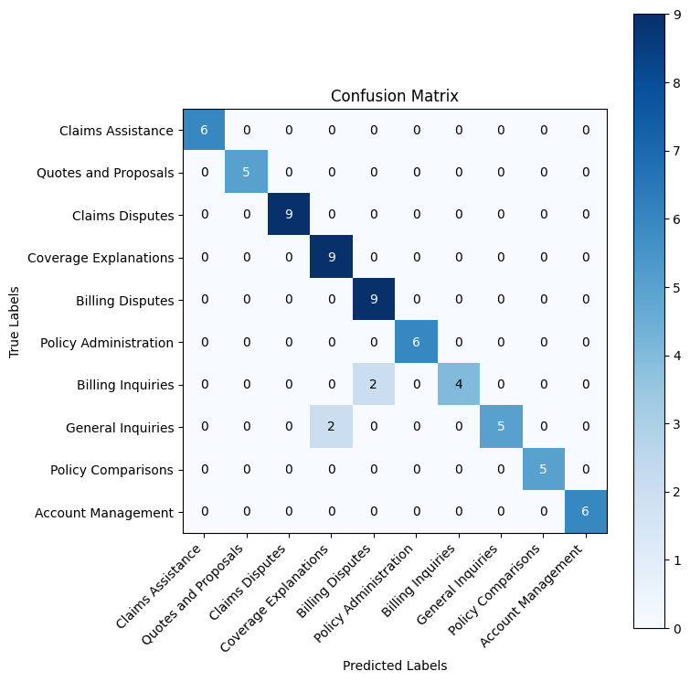

```python
print("Evaluating the RAG method on the test set...")
evaluate(X_test, y_test, rag_classify)
```

## RAG 결과 분석

RAG로 정확도가 약 70%에서 **94%**로 올랐습니다. 혼동 행렬의 대각선이 훨씬 뚜렷해졌고, 대부분의 범주가 완벽하거나 거의 완벽한 정확도에 도달했습니다.

남은 몇 건의 오류는 관련 예시가 있어도 일부 경계 사례는 여전히 모호하다는 뜻입니다. 여기서 생각의 사슬 추론이 Claude가 미묘한 구분을 더 신중히 따져 보도록 도울 수 있습니다.

## RAG에 생각의 사슬 추론 더하기

생각의 사슬(CoT) 프롬프팅은 분류를 결정하기 전에 Claude가 "소리 내어 생각"하게 합니다.

이 명시적인 추론 과정은 바로 분류할 때 놓칠 수 있는 미묘한 차이를 잡아내는 데 도움이 됩니다. 예를 들어 "청구서에 대해 질문이 있습니다"(청구 문의)와 "이 부과가 잘못된 것 같습니다"(청구 이의)를 구분하려면 의도와 어조를 이해해야 하는데, 단계별 분석이 여기에 도움이 됩니다.

`rag_chain_of_thought_classify` 함수는 Claude가 최종 `<category>`를 내놓기 전에 이 추론을 거치는 `<scratchpad>` 섹션을 추가합니다.

```python
def rag_chain_of_thought_classify(X):
    rag = vectordb.search(X, 5)
    rag_string = ""
    for example in rag:
        rag_string += textwrap.dedent(f"""
        <example>
            <query>
                "{example["metadata"]["text"]}"
            </query>
            <label>
                {example["metadata"]["label"]}
            </label>
        </example>
        """)
    prompt = (
        textwrap.dedent("""
    You will classify a customer support ticket into one of the following categories:
    <categories>
        {{categories}}
    </categories>

    Here is the customer support ticket:
    <ticket>
        {{ticket}}
    </ticket>

    Use the following examples to help you classify the query:
    <examples>
        {{examples}}
    </examples>

    First you will think step-by-step about the problem in scratchpad tags.
    You should consider all the information provided and create a concrete argument for your classification.

    Respond using this format:
    <response>
        <scratchpad>Your thoughts and analysis go here</scratchpad>
        <category>The category label you chose goes here</category>
    </response>
    """)
        .replace("{{categories}}", categories)
        .replace("{{ticket}}", X)
        .replace("{{examples}}", rag_string)
    )
    response = client.messages.create(
        messages=[
            {"role": "user", "content": prompt},
            {"role": "assistant", "content": "<response><scratchpad>"},
        ],
        stop_sequences=["</category>"],
        max_tokens=4096,
        temperature=0.0,
        model=MODEL,
    )

    # Extract the result from the response
    result = response.content[0].text.split("<category>")[1].strip()
    return result
```

```
Evaluating the RAG method with Chain of Thought on the test set...
                       precision    recall  f1-score   support

    Claims Assistance       1.00      1.00      1.00         6
 Quotes and Proposals       1.00      1.00      1.00         5
      Claims Disputes       1.00      1.00      1.00         9
Coverage Explanations       1.00      1.00      1.00         9
     Billing Disputes       0.82      1.00      0.90         9
Policy Administration       1.00      1.00      1.00         6
    Billing Inquiries       1.00      0.67      0.80         6
    General Inquiries       1.00      1.00      1.00         7
   Policy Comparisons       1.00      1.00      1.00         5
   Account Management       1.00      1.00      1.00         6

             accuracy                           0.97        68
            macro avg       0.98      0.97      0.97        68
         weighted avg       0.98      0.97      0.97        68
```

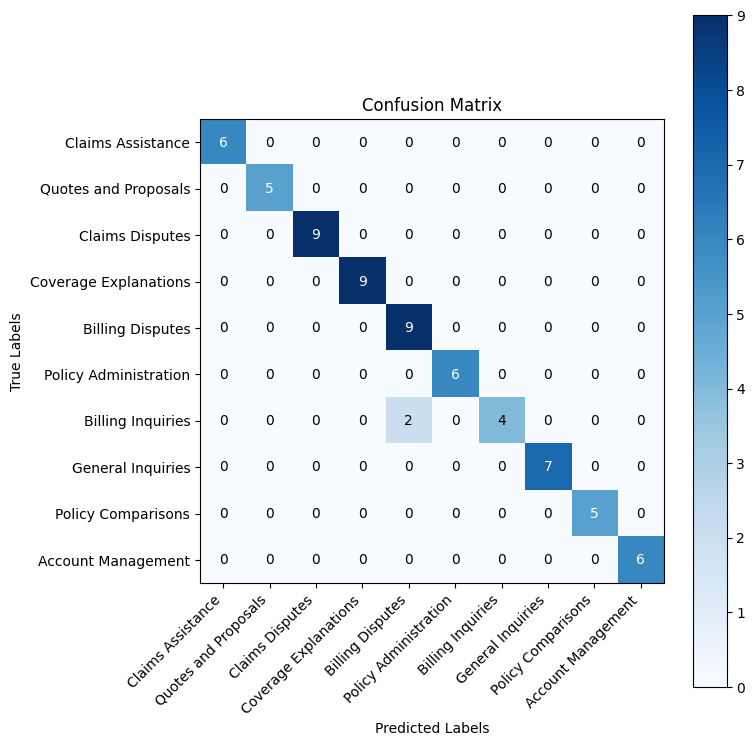

```python
print("Evaluating the RAG method with Chain of Thought on the test set...")
evaluate(X_test, y_test, rag_chain_of_thought_classify)
```

## 생각의 사슬 결과 분석

생각의 사슬 추론으로 정확도가 **97%**까지 올랐고, 앞선 방식들이 어려워하던 경계 사례 대부분이 해결되었습니다.

**단계별 개선 요약:**

- 무작위 기준점: 약 10% 정확도
- 간단한 분류기: 약 70% 정확도
- RAG 분류기: 94% 정확도
- **RAG + 생각의 사슬: 97% 정확도**

각 분류 결정을 명시적으로 추론함으로써 Claude가 모호한 경우를 더 잘 구분하게 되었습니다.

# Promptfoo로 평가 확장하기

이 가이드 전반에서 프롬프트를 설계할 때 **경험적 평가**가 얼마나 중요한지 보여 드렸습니다. 직감에 기대는 대신 각 단계에서 성능을 측정했습니다.

- 무작위 기준점: 약 10% → 간단한 분류기: 약 70% → RAG: 94% → RAG + CoT: 97%

이 데이터 기반 접근이 어떤 기법(RAG, 생각의 사슬)이 얼마나 가치를 더했는지 정확히 드러냈습니다. 이 방법론에 대해 더 알아보려면 [프롬프트 엔지니어링 가이드](https://docs.claude.com/en/docs/prompt-engineering)를 참고하세요.

## 노트북을 넘어서

주피터 노트북은 빠른 반복과 탐색에 훌륭하지만, 프로덕션 분류 시스템에는 더 견고한 평가 인프라가 필요합니다.

- **더 큰 테스트 세트**: 68개가 아니라 수백, 수천 개 예시로 평가하고 싶어집니다
- **여러 프롬프트 변형**: 서로 다른 표현, 구조, 접근을 A/B 테스트
- **모델 비교**: 여러 Claude 모델(Haiku vs Sonnet)이나 temperature 설정에 걸친 테스트
- **회귀 탐지**: 프롬프트 변경이 실수로 정확도를 떨어뜨리지 않도록 보장
- **버전 관리**: 시스템이 발전하는 동안 프롬프트 성능을 추적

여기서 [Promptfoo](https://www.promptfoo.dev/) 같은 전용 평가 도구가 필수적이 됩니다.

## Promptfoo 평가 실행하기

Promptfoo는 여러 설정에 걸쳐 프롬프트 테스트를 자동화하는 오픈소스 LLM 평가 도구입니다. 이 가이드에서는 세 가지 방식(간단, RAG, RAG+CoT)을 여러 temperature 설정에서 시험하는 Promptfoo 평가를 준비해 두었습니다.

**평가를 실행하려면:**

1. 평가 디렉터리로 이동: `cd ./evaluation`
2. `./evaluation/README.md`의 설정 안내를 따르세요
3. 평가를 실행한 뒤 여기로 돌아와 아래 결과를 분석하세요

결과는 각 프롬프트 변형이 전체 테스트 세트에서 어떻게 동작하는지 보여 주며, 노트북 테스트만으로는 드러나지 않는 패턴을 밝혀 줍니다.

```python
import json

import pandas as pd

promptfoo_results = pd.read_csv("./data/results.csv")
examples_columns = promptfoo_results.columns[2:]

number_of_providers = 5
number_of_prompts = 3

prompts = ["Simple", "RAG", "RAG w/ CoT"]

columns = ["label", "text"] + [
    json.loads(examples_columns[prompt * number_of_providers + provider])["provider"]
    + " Prompt: "
    + str(prompts[prompt])
    for prompt in range(number_of_prompts)
    for provider in range(number_of_providers)
]

promptfoo_results.columns = columns

result = (
    promptfoo_results.iloc[:, 2:].astype(str).apply(lambda x: x.str.count("PASS")).sum()
    / len(promptfoo_results)
    * 100
).sort_values(ascending=False)

print(result)
```

```
Haiku: T-0.0 Prompt: RAG w/ CoT    95.588235
Haiku: T-0.2 Prompt: RAG w/ CoT    95.588235
Haiku: T-0.8 Prompt: RAG w/ CoT    95.588235
Haiku: T-0.0 Prompt: RAG           94.117647
Haiku: T-0.4 Prompt: RAG           94.117647
Haiku: T-0.6 Prompt: RAG           94.117647
Haiku: T-0.4 Prompt: RAG w/ CoT    94.117647
Haiku: T-0.6 Prompt: RAG w/ CoT    94.117647
Haiku: T-0.2 Prompt: RAG           92.647059
Haiku: T-0.8 Prompt: RAG           89.705882
Haiku: T-0.6 Prompt: Simple        72.058824
Haiku: T-0.0 Prompt: Simple        70.588235
Haiku: T-0.2 Prompt: Simple        70.588235
Haiku: T-0.8 Prompt: Simple        70.588235
Haiku: T-0.4 Prompt: Simple        69.117647
dtype: float64
```

## Promptfoo로 하는 체계적 평가

위 결과는 규모 있는 체계적 프롬프트 평가의 힘을 보여 줍니다. 노트북이 개발 중 빠른 반복을 제공한 반면, [Promptfoo](https://www.promptfoo.dev/)는 여러 축에 걸쳐 프롬프트를 엄밀히 시험할 수 있게 해 주었습니다.

### 무엇을 시험했나

Promptfoo로 세 가지 프롬프트 방식(간단, RAG, RAG+CoT)을 다음 조건에서 평가했습니다.

- **여러 temperature 설정**(0.0, 0.2, 0.4, 0.6, 0.8): 결정론적 분류(T=0.0)가 약간의 무작위성이 있는 출력보다 나은지 확인
- **동일한 테스트 세트**(예시 68개): 모든 설정에서 공정한 비교 보장
- **자동 통과/실패 판정**: 각 예측을 정답 레이블과 자동으로 비교

### 주요 발견

Promptfoo 결과는 노트북에서의 발견을 확인해 주면서 추가적인 통찰도 보여 줍니다.

1. **CoT에는 temperature의 영향이 미미합니다**: RAG+CoT는 T=0.0, 0.2, 0.8에서 일관되게 95.59% 정확도를 보이며, 이는 생각의 사슬 추론이 샘플링 무작위성과 무관하게 출력을 안정시킨다는 뜻입니다
2. **RAG는 temperature 변화에 강건합니다**: RAG 성능이 대부분의 temperature 설정에서 89~94%로 견고하게 유지되며, T=0.0에서 가장 좋습니다(94.12%)
3. **간단한 프롬프트는 temperature와 무관합니다**: 간단한 분류기는 temperature와 관계없이 약 70% 정확도를 맴돌며, RAG나 CoT 없이는 모델이 주로 범주 정의에만 의존한다는 것을 확인해 줍니다
4. **프로덕션 권장 사항**: 최대의 일관성과 정확도(95.59%)를 위해 RAG+CoT와 함께 `temperature=0.0`을 사용하세요

직접 평가를 실행하려면 `./evaluation/README.md`의 설정 안내를 참고하세요.